# bulkseq endos analysis

This is an analysis performed on the bulk RNA-Seq dataset

The workflow is as follows:  
1. Inspect variance in the dataset (Filtering, Normalization, PCA)  
2. Perform differential expression analysis (Using limma)  
3. Annotate biological signatures found by DEA (GSEA)

### Counts list

```r
dat = read.csv('/Users/skander/Library/CloudStorage/OneDrive-Personnel/Documents/UDEM/Master/BulkData/data/Endo/mycountmatrix.csv',header = TRUE, sep = ";", row.names = 1 )
dat = subset(dat, select = -c(S91.1) )
knitr::kable(dat[1:10, 1:12], caption ="A Knitr kable")
```

|  | S114 | S115 | S116 | S117 | S118 | S121 | S122 | S123 | S124 | S125 | S126 | S127 |
| --- | --- | --- | --- | --- | --- | --- | --- | --- | --- | --- | --- | --- |
| ENSG00000000003 | 164.00 | 222.00 | 218.00 | 215.00 | 258.00 | 285.00 | 306.00 | 261.00 | 289.00 | 98.00 | 102.00 | 74.00 |
| ENSG00000000005 | 2.00 | 4.00 | 1.00 | 0.00 | 0.00 | 0.00 | 0.00 | 1.00 | 2.00 | 1.00 | 0.00 | 0.00 |
| ENSG00000000419 | 499.00 | 564.00 | 543.00 | 589.00 | 561.00 | 726.00 | 683.00 | 689.00 | 688.00 | 391.00 | 349.00 | 276.00 |
| ENSG00000000457 | 470.95 | 171.49 | 174.21 | 188.85 | 126.95 | 152.31 | 189.14 | 184.29 | 175.25 | 667.27 | 583.16 | 526.56 |
| ENSG00000000460 | 68.05 | 158.51 | 153.79 | 141.15 | 306.05 | 357.69 | 294.86 | 303.71 | 300.75 | 56.73 | 47.84 | 37.44 |
| ENSG00000000938 | 1.00 | 1.00 | 0.00 | 2.00 | 0.00 | 0.00 | 0.00 | 0.00 | 1.00 | 4.00 | 0.00 | 0.00 |
| ENSG00000000971 | 32098.85 | 6987.76 | 7215.98 | 7405.73 | 3545.06 | 3412.99 | 2802.98 | 3201.92 | 3255.76 | 20662.66 | 17773.85 | 14512.06 |
| ENSG00000001036 | 893.02 | 1030.37 | 974.90 | 1052.08 | 974.84 | 848.96 | 836.29 | 864.86 | 797.46 | 615.99 | 576.29 | 448.47 |
| ENSG00000001084 | 635.00 | 807.00 | 881.00 | 822.00 | 520.00 | 324.00 | 331.00 | 387.00 | 316.00 | 365.00 | 342.00 | 296.00 |
| ENSG00000001167 | 404.00 | 499.00 | 472.00 | 467.00 | 539.00 | 594.00 | 637.00 | 613.00 | 574.00 | 314.00 | 269.00 | 254.00 |

A Knitr kable

```r
#length(colnames(dat))
#write.csv(dat,'/Users/skander/Library/CloudStorage/OneDrive-Personnel/Documents/UDEM/Master/BulkData/data/Endo/mycountmatrix2nov22.csv')
```

### Meta data

```r
meta = read.xlsx('/Users/skander/Library/CloudStorage/OneDrive-Personnel/Documents/UDEM/Master/BulkData/data/Endo/20220721_Metadata_bulkseq_endos_run1.xlsx')
rownames(meta) <- paste0("S",meta$New.tube.label,sep = "")
meta$RNA.iso.date <- as.Date(meta$RNA.iso.date, origin="1900-01-01")
meta$RNA.iso.date <- factor(meta$RNA.iso.date)
meta$Prep <- factor(meta$Prep)
names(meta)[names(meta) == "Proj.3(Cyto)"] <- "proj.Cyto"
names(meta)[names(meta) == "Proj1(37)"] <- "proj.IL37"
names(meta)[names(meta) == "Proj2(IL4)"] <- "proj.IL4"
names(meta)[names(meta) == "Flowcell#"] <- "Flowcell"
meta$proj.Cyto[2]="Cyto"
meta$proj.Cyto[5]="Cyto"
meta$stim[8]="IL1b"

meta$stim=gsub("40% ACM","ACM40",meta$stim)
meta$condition <- "NA"
meta$stimConc = "NA"
for(i in 1:nrow(meta)){
    if(meta$stim[i]=="IL23"|meta$stim[i]=="IL1b"|meta$stim[i]=="TNFa"|meta$stim[i]=="IFNg"|meta$stim[i]=="IL6"|meta$stim[i]=="IL17"|meta$stim[i]=="GMCSF"){
        meta$condition[i] <- "ProInflammatory"
    }
    else if(meta$stim[i]=="IL35"|meta$stim[i]=="IL10"|meta$stim[i]=="TGFB1"|meta$stim[i]=="IL37"|meta$stim[i]=="IL4"){
        meta$condition[i]<-"AntiInflammatory"
    }
    else if(meta$stim[i]=="IT"|meta$stim[i]=="ECM"|meta$stim[i]=="ACM40"){
        meta$condition[i]<-"Control"
    }
    else{
        meta$condition[i]<-"ControlAntiInflammtory"
    }
}

#for(i in 1:nrow(meta)){
#    if(rownames(meta)[i]=="S109"){
#        meta$test[i] <- "109"
#    }
#    else if(rownames(meta)[i]=="S110"){
#        meta$test[i] <- "110"
#    }
#    else if(rownames(meta)[i]=="S111"){
#        meta$test[i] <- "111"
#    }
#    else if(rownames(meta)[i]=="S197"){
#        meta$test[i] <- "197"
#    }
#    else if(rownames(meta)[i]=="S198"){
#        meta$test[i] <- "198"
#    }
#    else if(rownames(meta)[i]=="S199"){
#        meta$test[i] <- "199"
#    }
#    else{
#        meta$test[i] <- "other"
#    }
#}

meta <- meta %>% dplyr::select(Prep,size,p,stim,condition, everything())
genomic_idx <- match(rownames(meta), colnames(dat))
dat  <- dat[ , genomic_idx]
meta$sizeMerge = "NA"
for(i in 1:nrow(meta)){
    if(meta$size[i]==">30"|meta$size[i]=="<30"){
        meta$sizeMerge[i] <- "HMEC"
    }
    else{
        meta$sizeMerge[i] <- "HBEC"
    }
}


knitr::kable(meta[,1:11], caption ="A Knitr kable")
```

|  | Prep | size | p | stim | condition | proj.IL37 | proj.IL4 | proj.Cyto | Flowcell | conc | Run.# |
| --- | --- | --- | --- | --- | --- | --- | --- | --- | --- | --- | --- |
| S91 | 241 | 112 | 3 | IL37 | AntiInflammatory | IL37 | NA | NA | HFFTKBGXM | 1ng/ml | 4 |
| S92 | 241 | 112 | 3 | IL37 | AntiInflammatory | IL37 | NA | Cyto | HFFTKBGXM | 10ng/ml | 4 |
| S93 | 241 | 112 | 3 | IL37 | AntiInflammatory | IL37 | NA | NA | HFFTKBGXM | 100ng/ml | 4 |
| S94 | 241 | 112 | 3 | IL4 | AntiInflammatory | NA | IL4 | NA | HFFTKBGXM | 1ng/ml | 4 |
| S95 | 241 | 112 | 3 | IL4 | AntiInflammatory | NA | IL4 | Cyto | HFFTKBGXM | 10ng/ml | 4 |
| S96 | 241 | 112 | 3 | IL4 | AntiInflammatory | NA | IL4 | NA | HFFTKBGXM | 100ng/ml | 4 |
| S97 | 241 | 112 | 3 | IL23 | ProInflammatory | NA | NA | Cyto | HFFTKBGXM | 100ng/ml | 5 |
| S98 | 241 | 112 | 3 | IL1b | ProInflammatory | NA | NA | Cyto | HFFTKBGXM | 1ng/ml | 5 |
| S99 | 241 | 112 | 3 | IL6 | ProInflammatory | NA | NA | Cyto | HFFTKBGXM | 100ng/ml | 5 |
| S100 | 241 | 112 | 3 | it+37 | ControlAntiInflammtory | IL37 | NA | NA | HFFTKBGXM | 1ng/ml | 5 |
| S101 | 241 | 112 | 3 | it+37 | ControlAntiInflammtory | IL37 | NA | NA | HFFTKBGXM | 10ng/ml | 5 |
| S102 | 241 | 112 | 3 | it+37 | ControlAntiInflammtory | IL37 | NA | NA | HFFTKBGXM | 100ng/ml | 5 |
| S103 | 241 | 112 | 3 | it+IL4 | ControlAntiInflammtory | NA | IL4 | NA | HFFTKBGXM | 1ng/ml | 5 |
| S104 | 241 | 112 | 3 | it+IL4 | ControlAntiInflammtory | NA | IL4 | NA | HFFTKBGXM | 10ng/ml | 5 |
| S105 | 241 | 112 | 3 | it+IL4 | ControlAntiInflammtory | NA | IL4 | NA | HFFTKBGXM | 100ng/ml | 5 |
| S106 | 241 | 112 | 3 | IL10 | AntiInflammatory | NA | NA | Cyto | HFFTKBGXM | 1ng/ml | 5 |
| S107 | 241 | 112 | 3 | TGFB1 | AntiInflammatory | NA | NA | Cyto | HFFTKBGXM | 100ng/ml | 5 |
| S109 | 241 | 112 | 3 | IL17 | ProInflammatory | NA | NA | Cyto | HFFTKBGXM | 100ng/ml | 5 |
| S110 | 241 | 112 | 3 | GMCSF | ProInflammatory | NA | NA | Cyto | HFFTKBGXM | 100ng/ml | 5 |
| S111 | 241 | 112 | 3 | IL35 | AntiInflammatory | NA | NA | Cyto | HFFTKBGXM | 10ng/ml | 5 |
| S114 | 241 | 112 | 3 | ECM | Control | IL37 | IL4 | Cyto | H2V22BGXM | NA | 5 |
| S115 | 241 | 112 | 3 | ACM40 | Control | IL37 | IL4 | Cyto | H2V22BGXM | NA | 5 |
| S116 | 241 | 112 | 3 | IT | Control | IL37 | IL4 | Cyto | H2V22BGXM | NA | 5 |
| S117 | 241 | 112 | 3 | IFNg | ProInflammatory | NA | NA | Cyto | H2V22BGXM | NA | 5 |
| S118 | 241 | 112 | 3 | TNFa | ProInflammatory | NA | NA | Cyto | H2V22BGXM | NA | 5 |
| S121 | 240 | 112 | 3 | it+IL4 | ControlAntiInflammtory | NA | IL4 | NA | H2V22BGXM | 1ng/ml | 6 |
| S122 | 240 | 112 | 3 | it+IL4 | ControlAntiInflammtory | NA | IL4 | NA | H2V22BGXM | 10ng/ml | 6 |
| S123 | 240 | 112 | 3 | it+IL4 | ControlAntiInflammtory | NA | IL4 | NA | H2V22BGXM | 100ng/ml | 6 |
| S124 | 240 | 112 | 3 | it+37 | ControlAntiInflammtory | IL37 | NA | NA | H2V22BGXM | 1ng/ml | 6 |
| S125 | 240 | 112 | 3 | it+37 | ControlAntiInflammtory | IL37 | NA | NA | H2V22BGXM | 10ng/ml | 6 |

[output cut: 70 more lines]

A Knitr kable

```r
#write.xlsx(meta, "/Users/skander/Library/CloudStorage/OneDrive-Personnel/Documents/UDEM/Master/BulkData/data/Endo/Metadata_endos_2nov22.xlsx",  col.names = TRUE, row.names = TRUE, append = FALSE)
```

```r
metaF = read.xlsx('/Users/skander/Library/CloudStorage/OneDrive-Personnel/Documents/UDEM/Master/BulkData/data/Endo/20220815_Overview_bulkseq_endo_cytokines_FIXED_v1.xlsx')
rownames(metaF) <- paste0("S",metaF$New.tube.label,sep = "")
names(metaF)[names(metaF) == "Flowcell#"] <- "Flowcell"
genomic_idx <- match(rownames(meta), colnames(dat))
dat  <- dat[ , genomic_idx]
metaF$Cytokine <- gsub("TGFB1","TGFb1",metaF$Cytokine)
metaF$Cytokine <- gsub("TGFB","TGFb1",metaF$Cytokine)
metaF$Cytokine <- gsub("IL1B","IL1b",metaF$Cytokine)
#knitr::kable(metaF, caption ="A Knitr kable")

sign_cols=c(DN='deepskyblue',NS='grey80',UP='tomato')
go = read.gmt('/Users/skander/Library/CloudStorage/OneDrive-Personnel/Documents/UDEM/Master/BulkData/GO/c5.go.bp.v7.5.1.symbols.gmt')
mf = read.gmt('/Users/skander/Library/CloudStorage/OneDrive-Personnel/Documents/UDEM/Master/BulkData/GO/c5.go.mf.v7.5.1.symbols.gmt')
kegg = read.gmt('/Users/skander/Library/CloudStorage/OneDrive-Personnel/Documents/UDEM/Master/BulkData/GO/c2.cp.kegg.v7.5.1.symbols.gmt')
tft = read.gmt('/Users/skander/Library/CloudStorage/OneDrive-Personnel/Documents/UDEM/Master/BulkData/GO/c3.tft.v7.5.1.symbols.gmt')
## Differential expression analysis with limma-voom

### Filtering to remove lowly expressed genes + Normalization for composition bias

d0 <- DGEList(dat)
d0 <- calcNormFactors(d0)
cutoff <- 2
drop <- which(apply(edgeR::cpm(d0), 1, max) < cutoff)
d <- d0[-drop,]


mmF <- model.matrix(~ 0 + Cytokine, data=metaF[colnames(d),])
yF <- voom(d, mmF, plot = F)
```

## Differential expression analysis with limma-voom

### Filtering to remove lowly expressed genes

#### Genes with very low counts across all libraries provide little evidence for differential expression and they interfere with some of the statistical approximations that are used later in the pipeline. They also add to the multiple testing burden when estimating false discovery rates, reducing power to detect differentially expressed genes. These genes should be filtered out prior to further analysis.

```r
d0 <- DGEList(dat)
d0 <- calcNormFactors(d0)
cutoff <- 2
drop <- which(apply(edgeR::cpm(d0), 1, max) < cutoff)
d <- d0[-drop,]
```

### Library size and distribution plots

#### Plot the library sizes as a barplot to see whether there are any major discrepancies between the samples more easily.

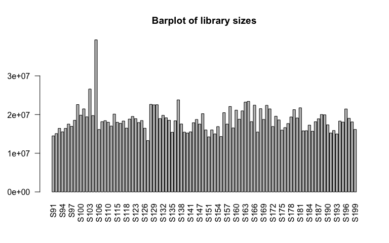

```r
barplot(d$samples$lib.size,names=colnames(d),las=2)
title("Barplot of library sizes")
```

#### Box plots to check the distribution of the read counts on the log2 scale

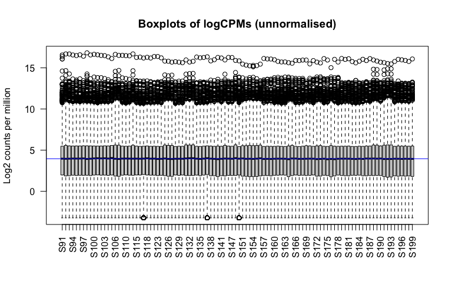

```r
# Get log2 counts per million
logcounts <- cpm(d,log=TRUE)
# Check distributions of samples using boxplots
boxplot(logcounts, xlab="", ylab="Log2 counts per million",las=2)
# Let's add a blue horizontal line that corresponds to the median logCPM
abline(h=median(logcounts),col="blue")
title("Boxplots of logCPMs (unnormalised)")
```

### Normalization for composition bias

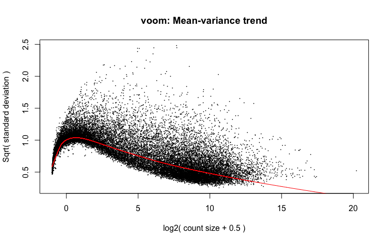

```r
mm <- model.matrix(~ 0 + stim + Flowcell , data=meta[colnames(d),])

# Without filtering low expressed genes
y <- voom(d0, mm, plot = T)
```

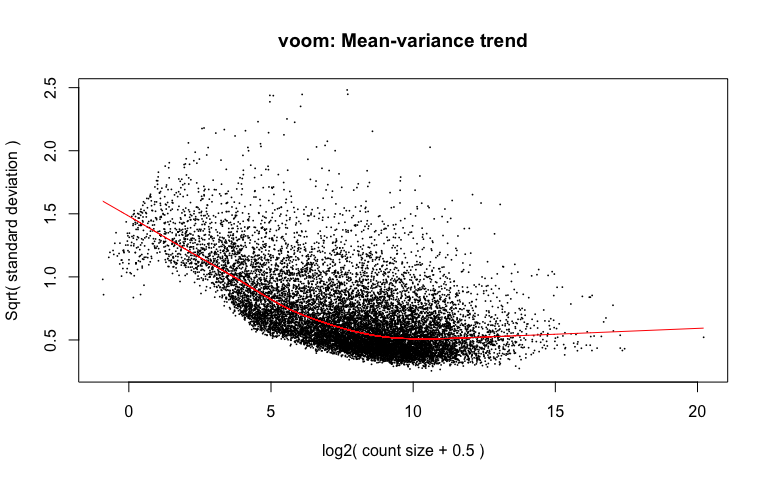

```r
# Filtering low expressed genes
y <- voom(d, mm, plot = T)
```

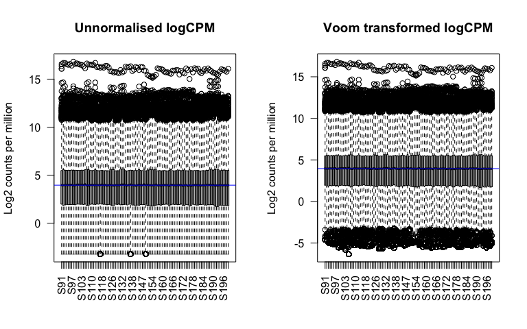

```r
par(mfrow=c(1,2))
boxplot(logcounts, xlab="", ylab="Log2 counts per million",las=2,main="Unnormalised logCPM")
## Let's add a blue horizontal line that corresponds to the median logCPM
abline(h=median(logcounts),col="blue")
boxplot(y$E, xlab="", ylab="Log2 counts per million",las=2,main="Voom transformed logCPM")
## Let's add a blue horizontal line that corresponds to the median logCPM
abline(h=median(y$E),col="blue")
```

```r
##gene name reference(ref_G)
conv_B=AnnotationDbi::select(org.Hs.eg.db,keys=rownames(y$E),keytype='ENSEMBL',columns=c('GENENAME','SYMBOL'))
ref_G=conv_B[!duplicated(conv_B[,1]),]
rownames(ref_G)=ref_G[,1]
##
```

```r
labels <- paste(rownames(meta), meta$stim)
group <- factor(paste(meta$condition,meta$size,sep="."))
glimmaMDS(d, labels=labels, groups=group, width=1200, height=1000,main = "MDS Plot", path = getwd(), folder = "glimma-plots", html = "MDS-Plot", launch = TRUE)
#glMDSPlot(d, labels=labels, groups=group, folder="mds")
```

## PCA

Perform a *PCA* on the normalized samples and identify main factors of variation.

```r
# ### PCA ALL PROJECT Version Modif
# pcaF = prcomp(t(yF$E))
# metaF=metaF[colnames(yF$E),]
# metaF$PC1 = pcaF$x[,1]
# metaF$PC2 = pcaF$x[,2]
# meta=data.frame(meta)
# autoplot(pcaF,data=meta,col="Flowcell",title ="flowcell")
# autoplot(pcaF,data=meta,col='size',title ="size",label = TRUE)
# autoplot(pcaF,data=meta,col='stim',title ="stim")
```

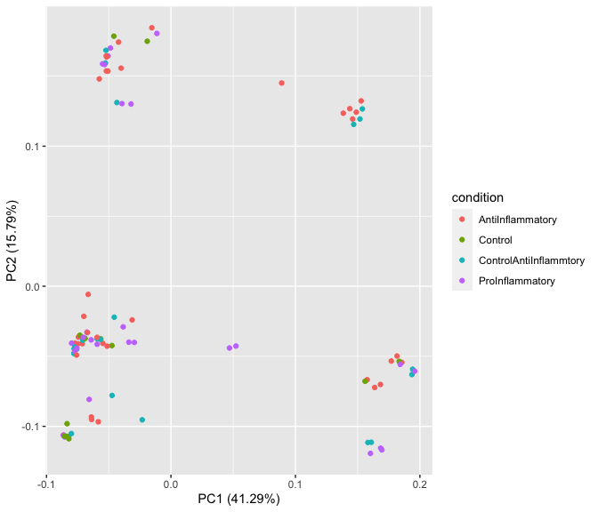

```r
### PCA ALL PROJECT First Version
pca = prcomp(t(y$E))
meta=meta[colnames(y$E),]
meta$PC1 = pca$x[,1]
meta$PC2 = pca$x[,2]
meta=data.frame(meta)
#autoplot(pca,data=meta,col='test',title ="condition", label = TRUE, label.size = 5)
autoplot(pca,data=meta,col='condition',title ="condition")
```

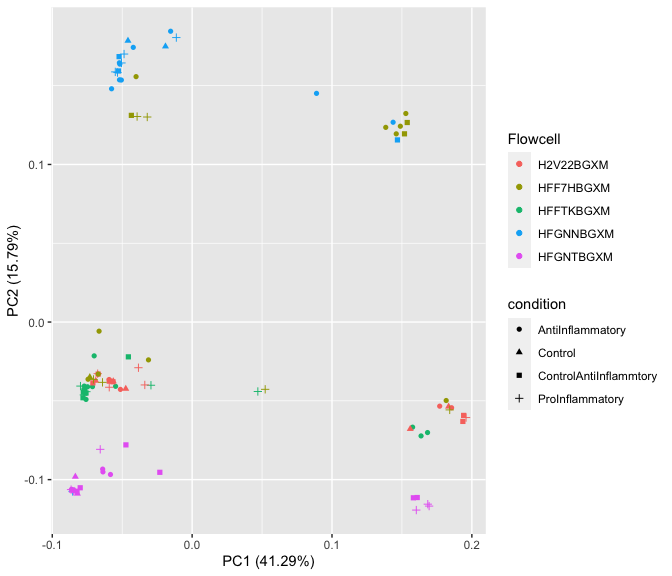

```r
autoplot(pca,data=meta,col="Flowcell",shape="condition",title ="flowcell")
```

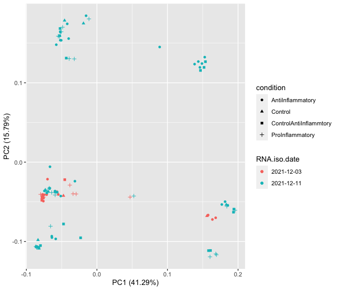

```r
autoplot(pca,data=meta,col='RNA.iso.date',shape="condition",title ="RNA.iso.date")
```

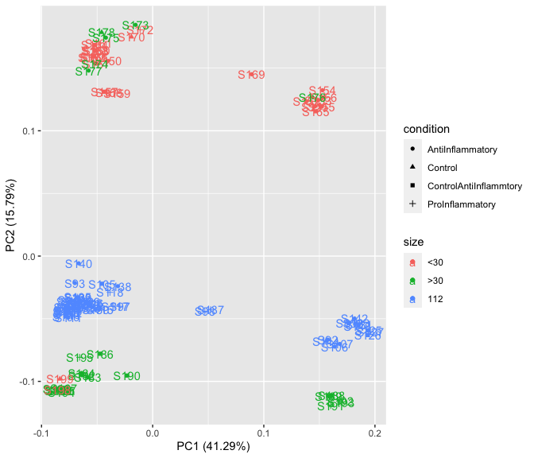

```r
autoplot(pca,data=meta,col='size',shape="condition",title ="size",label = TRUE)
```

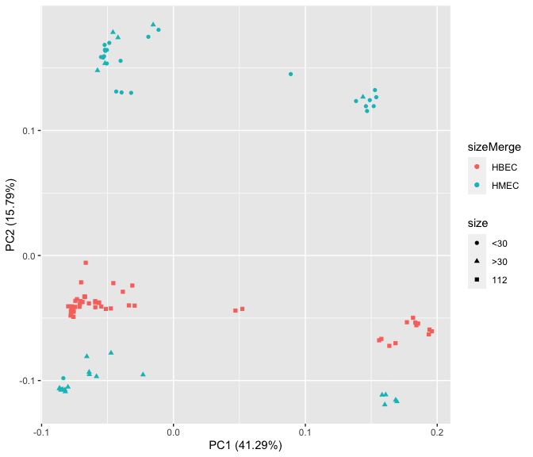

```r
autoplot(pca,data=meta,col='sizeMerge',shape="size",title ="size")
```

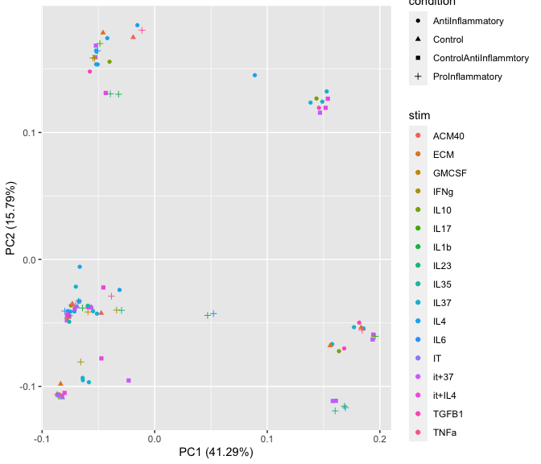

```r
autoplot(pca,data=meta,col='stim',shape="condition",title ="stim")
```

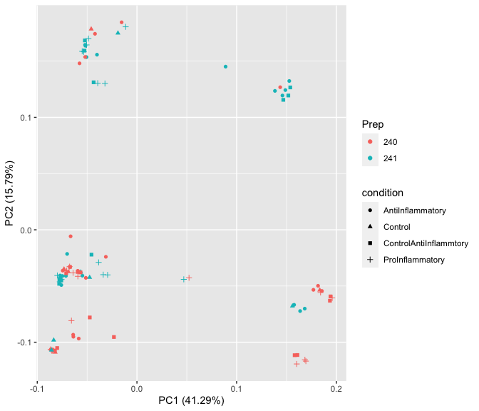

```r
autoplot(pca,data=meta,col='Prep',shape="condition",title ="Prep")
```

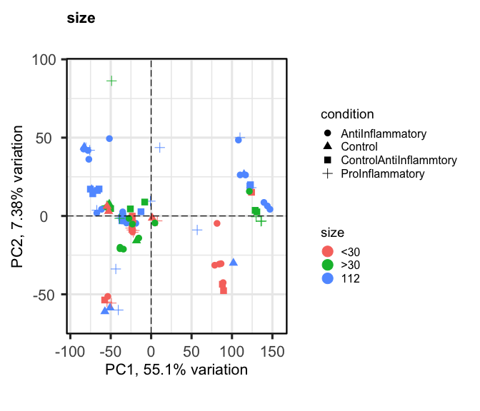

```r
#BDCorrB <- removeBatchEffect(y$E,batch = meta$Flowcell)
#BD1B <- prcomp(t(BDCorrB))
#autoplot(BD1B,data=meta,col="Flowcell",title ="flowcell")

BDCorrB <- removeBatchEffect(y$E,batch = meta$Flowcell)
BD1B <- pca(BDCorrB, metadata = meta)
biplot(BD1B, colby = 'size',shape = 'condition', hline = 0, vline = 0,legendPosition = 'right', lab="",title="size")
```

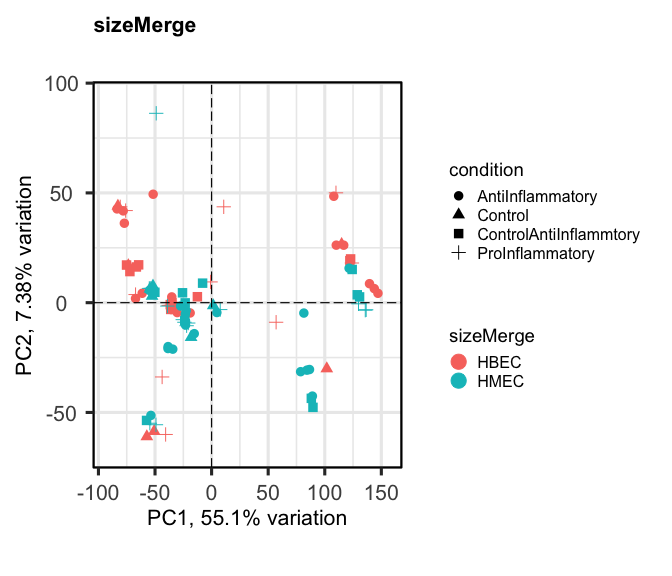

```r
biplot(BD1B, colby = 'sizeMerge',shape = 'condition', hline = 0, vline = 0,legendPosition = 'right', lab="",title="sizeMerge")
```

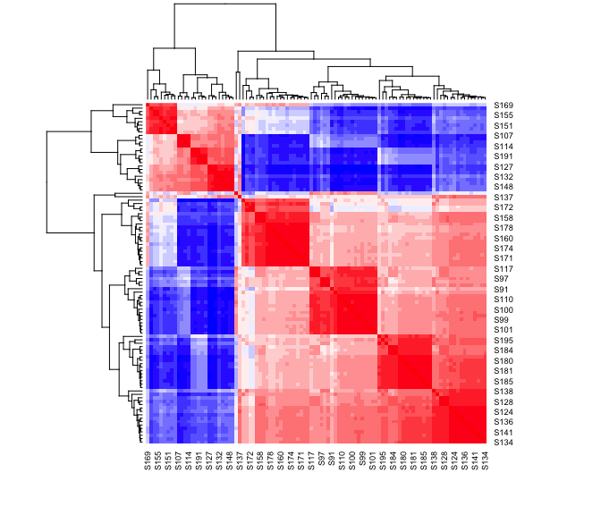

```r
mcor <- cor(y$E)
#library(corrplot)
#corrplot(mcor,type="upper", order="hclust",tl.col="black", tl.srt=45)
col <- colorRampPalette(c("blue","white","red"))(20)
heatmap(x=mcor, col=col, symm=TRUE)
```

## Differential expression analysis with limma-voom (My project Cyto)

### Filtering to remove lowly expressed genes + Normalization for composition bias

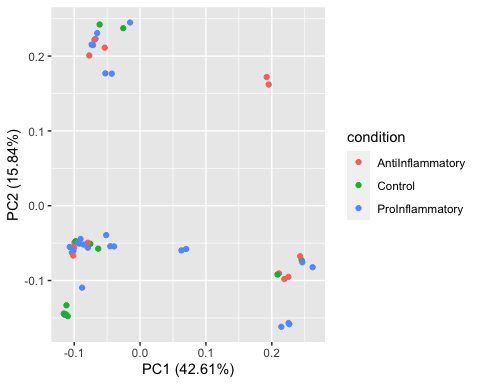

```r
d0 <- DGEList(dat)
d0 <- calcNormFactors(d0)
cutoff <- 2
drop <- which(apply(edgeR::cpm(d0), 1, max) < cutoff)
d <- d0[-drop,]

metaCyto <- subset(meta, proj.Cyto=="Cyto")
mmC <- model.matrix(~ 0 +stim+Flowcell, data=metaCyto[colnames(d),])


# Filtering low expressed genes
yC <- voom(d[,rownames(metaCyto)], mmC, plot = F)

pcaC = prcomp(t(yC$E))
metaCyto=metaCyto[colnames(yC$E),]
autoplot(pcaC,data=metaCyto,col="condition",title ="condition")
```

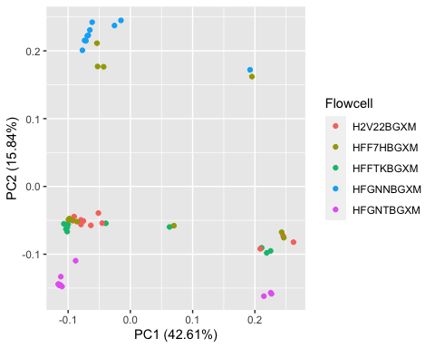

```r
autoplot(pcaC,data=metaCyto,col="Flowcell",title ="Flowcell")
```

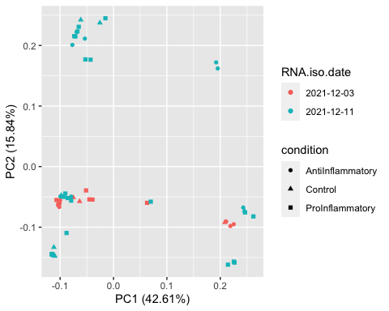

```r
autoplot(pcaC,data=metaCyto,col='RNA.iso.date',shape="condition",title ="RNA.iso.date")
```

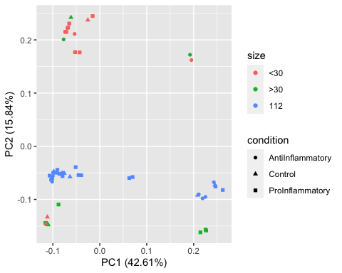

```r
autoplot(pcaC,data=metaCyto,col='size',shape="condition",title ="size")
```

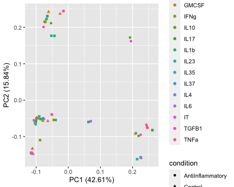

```r
autoplot(pcaC,data=metaCyto,col='stim',shape="condition",title ="stim")
```

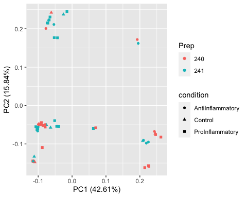

```r
autoplot(pcaC,data=metaCyto,col='Prep',shape="condition",title ="Prep")
```

## Plot Gene

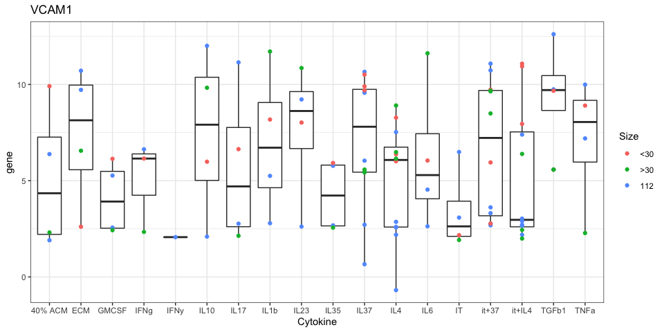

```r
meta$stimConc <- paste(meta$stim,meta$conc)
meta$stimConc <- gsub("ng/ml","",meta$stimConc)
meta$stimConc <- gsub("NA","",meta$stimConc)

plot.geneF <- function(x){
    geneEns <- subset(ref_G,SYMBOL==x)$ENSEMBL
    metaF$gene = yF$E[geneEns,rownames(metaF)]
    ggplot(metaF,aes(Cytokine,gene))+geom_boxplot()+geom_point(aes(col=Size))+ggtitle(x)+theme_bw()
}
plot.gene <- function(x){
    geneEns <- subset(ref_G,SYMBOL==x)$ENSEMBL
    meta$gene = y$E[geneEns,rownames(meta)]
    ggplot(meta,aes(stimConc,gene))+geom_boxplot()+geom_point(aes(col=sizeMerge))+ggtitle(x)+theme_bw()+theme(axis.text.x=element_text(angle=60,hjust=1))
}

metaF$New.tube.label <- factor(metaF$New.tube.label)
metaF$conc <- factor(metaF$conc)
plot.geneIl37 <- function(x){
    geneEns <- subset(ref_G,SYMBOL==x)$ENSEMBL
    metaF$gene = yF$E[geneEns,rownames(metaF)]
    ggplot(metaF[c("S100","S101","S102","S124","S125","S126","S164","S165","S166","S188","S189","S190"),],aes(conc,gene))+geom_boxplot()+geom_point(aes(col=New.tube.label))+ggtitle(x)+theme_bw()
}


plot.geneF("VCAM1")
```

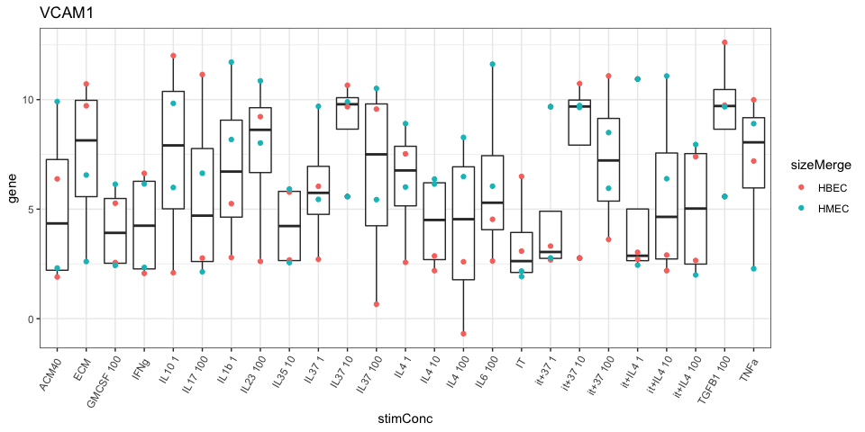

```r
plot.gene("VCAM1")
```

```r
#plot.geneIl37("GBP1")
```

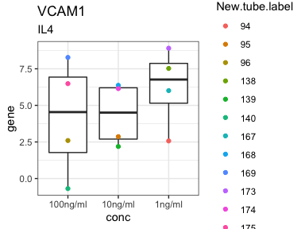

```r
meta$New.tube.label <- factor(meta$New.tube.label)
meta$conc <- factor(meta$conc)
plot.geneSubset <- function(x){
    geneEns <- subset(ref_G,SYMBOL==x)$ENSEMBL
    meta$gene = y$E[geneEns,rownames(meta)]
    y="IL4"
    ggplot(subset(meta,stim==y),aes(conc,gene))+geom_boxplot()+geom_point(aes(col=New.tube.label))+ggtitle(label = x,
              subtitle = y)+theme_bw()
}
plot.geneSubset("VCAM1")
```

## Clustering

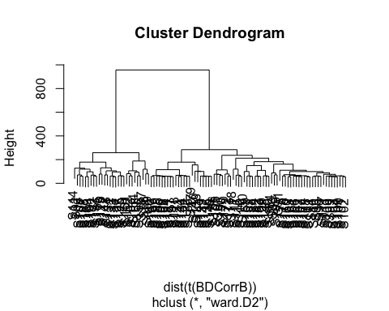

```r
hc=hclust(dist(t(BDCorrB)), method='ward.D2')
hc_clus=data.frame(cutree(hc, k=3))
hc_clus[,1]=paste0('C',hc_clus[,1])
meta$clus_hm=hc_clus[rownames(meta),1]
t=data.frame(table(meta$clus_hm))

plot(hc)
```

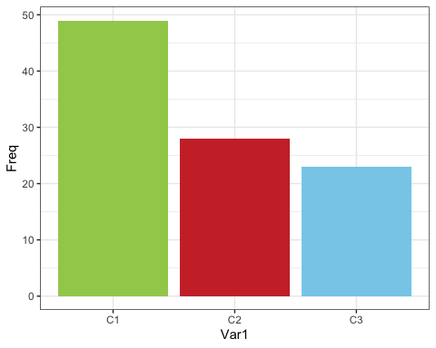

```r
ggplot(t,aes(Var1,Freq))+geom_col(fill=c('darkolivegreen3','brown3','skyblue'))+theme_bw()
```

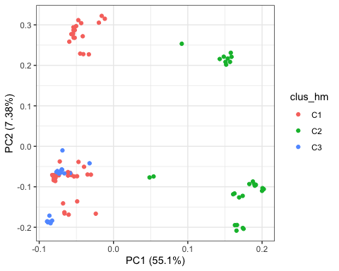

```r
autoplot(prcomp(t(BDCorrB)),data=meta, col='clus_hm')+theme_bw()
```

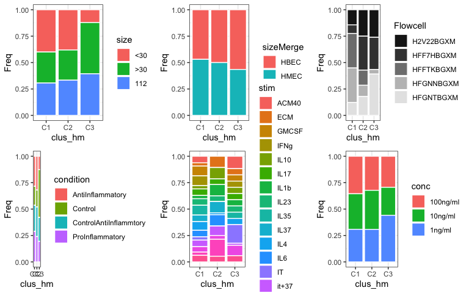

```r
summarize_col<-function(col){
  t=table(meta[,c('clus_hm' ,col)])
  for(i in 1:ncol(t)){t[,i]=t[,i]/sum(t[,i])}
  for(i in 1:nrow(t)){t[i, ]=t[i,]/sum(t[i,])}
  t=data.frame(t)
  p=ggplot(t,aes(clus_hm,Freq,fill=t[,col]))+geom_col(col='white')+labs(fill=col)+theme_bw()
return(p)
}

#p1=summarize_col('New.tube.label')
p2=summarize_col('size')
p3=summarize_col('sizeMerge')
p4=summarize_col('Flowcell')+scale_fill_manual(values=c('grey10','grey25','grey50','grey75','grey90'))
p5=summarize_col('condition')
p6=summarize_col('stim')
p7=summarize_col('conc')

cowplot::plot_grid(p2,p3,p4,p5,p6,p7,ncol=3)
```

## Comparisons between cluster

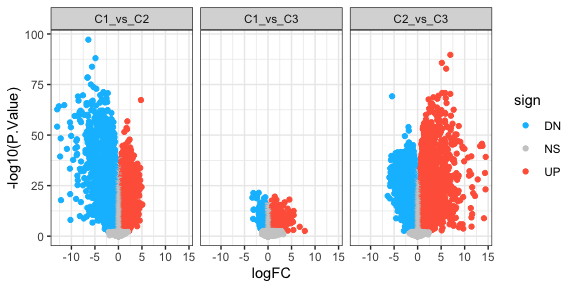

```r
mmG <- model.matrix(~ 0 + clus_hm+Flowcell, data=meta[colnames(d),])

# Filtering low expressed genes
yG <- voom(d[,rownames(meta)], mmG, plot = F)

fitG <- lmFit(yG, mmG)
contrG <- makeContrasts(
  A = clus_hmC1 - clus_hmC2,
  B = clus_hmC1 - clus_hmC3,
  C = clus_hmC2 - clus_hmC3,
  levels = colnames(coef(fitG)))
tmpG <- contrasts.fit(fitG, contrG)
tmpG <- eBayes(tmpG)

res <- list()
res[['C1_vs_C2']] <- topTable(tmpG, sort.by = "P", n = Inf,coef='A')
res[['C1_vs_C3']] <- topTable(tmpG, sort.by = "P", n = Inf,coef='B')
res[['C2_vs_C3']] <- topTable(tmpG, sort.by = "P", n = Inf,coef='C')

res[['C1_vs_C2']]$comp='C1_vs_C2'
res[['C1_vs_C3']]$comp='C1_vs_C3'
res[['C2_vs_C3']]$comp='C2_vs_C3'
res=do.call(rbind,res)
res$sign = 'NS'
res[which(res$adj.P.Val<0.01&res$logFC>0.5),'sign']='UP'
res[which(res$adj.P.Val<0.01&res$logFC<(-0.5)),'sign']='DN'
res$gene_name=ref_G[gsub(".+\\.","",rownames(res)),3]

ggplot(res,aes(logFC,-log10(P.Value),col=sign))+geom_point()+facet_grid(~comp)+theme_bw()+scale_color_manual(values=sign_cols)
```

## Gene set enrichment analysis(PCA)

```r
pca = prcomp(t(BDCorrB))$x[,1:2]
pvals=c()
est=c()
for(i in 1:nrow(BDCorrB)){
  pvals = c(pvals,cor.test(BDCorrB[i,],pca[,1])$p.value)
  est = c(est,cor.test(BDCorrB[i,],pca[,1])$estimate)
}
names(pvals)=rownames (BDCorrB)
names(pvals)=ref_G[names(pvals),3]
pvals=pvals[!is.na(names(pvals))]

names(est)=rownames(BDCorrB)
names(est)=ref_G[names(est),3]
est=est[!is.na(names(est))]

df = data.frame(cbind(pvals,est[names(pvals)]))
df$gene = rownames(df)
pvals=c()
est=c()
for(i in 1:nrow(BDCorrB)){
  pvals = c(pvals,cor.test(BDCorrB[i,],pca[,2])$p.value)
  est = c(est,cor.test(BDCorrB[i, ],pca[,2])$estimate)
}
names(pvals)=rownames(BDCorrB)
names(pvals)=ref_G[names(pvals),3]
pvals=pvals[!is.na(names(pvals))]

names(est)=rownames(BDCorrB)
names(est)=ref_G[names(est),3]
est=est[!is.na(names(est))]

df2=data.frame(cbind(pvals,est[names(pvals)]))

df$pval_pc2=df2[rownames(df),1]
df$est_pc2=df2[rownames(df),2]

vec1=df[,2]
vec2=df[,4]

names(vec1)=rownames(df)
names(vec2)=rownames(df)

gsea_res1=fgsea(pathways=go,stats=vec1)
gsea_res2=fgsea(pathways=go,stats=vec2)

head(gsea_res1[order(gsea_res1$padj),],30)
```

```
##                                                                            pathway
##  1:                                                          GOBP_DEFENSE_RESPONSE
##  2:                                                           GOBP_IMMUNE_RESPONSE
##  3:                                        GOBP_DEFENSE_RESPONSE_TO_OTHER_ORGANISM
##  4: GOBP_BIOLOGICAL_PROCESS_INVOLVED_IN_INTERSPECIES_INTERACTION_BETWEEN_ORGANISMS
##  5:                                                    GOBP_INNATE_IMMUNE_RESPONSE
##  6:                                       GOBP_REGULATION_OF_IMMUNE_SYSTEM_PROCESS
##  7:                                                      GOBP_RESPONSE_TO_CYTOKINE
##  8:                                             GOBP_REGULATION_OF_IMMUNE_RESPONSE
##  9:                                                        GOBP_CELL_CYCLE_PROCESS
## 10:                              GOBP_POSITIVE_REGULATION_OF_IMMUNE_SYSTEM_PROCESS
## 11:                                       GOBP_CYTOKINE_MEDIATED_SIGNALING_PATHWAY
## 12:                                                                GOBP_CELL_CYCLE
## 13:                                                        GOBP_MITOTIC_CELL_CYCLE
## 14:                                                GOBP_MITOTIC_CELL_CYCLE_PROCESS
```

[output cut: 81 more lines]

```r
head(gsea_res2[order(gsea_res2$padj),],30)
```

```
##                                                                                                  pathway
##  1:                                                GOBP_TRIGLYCERIDE_RICH_LIPOPROTEIN_PARTICLE_CLEARANCE
##  2:                                                             GOBP_NOREPINEPHRINE_BIOSYNTHETIC_PROCESS
##  3:                                                        GOBP_REGULATION_OF_CARDIOCYTE_DIFFERENTIATION
##  4:                                               GOBP_POSITIVE_REGULATION_OF_CARDIOCYTE_DIFFERENTIATION
##  5:                                                                     GOBP_DENDRITIC_SPINE_DEVELOPMENT
##  6:                                                                        GOBP_LUNG_SACCULE_DEVELOPMENT
##  7:                                                          GOBP_PROTEIN_LOCALIZATION_TO_EARLY_ENDOSOME
##  8:                                                                          GOBP_MOTOR_NEURON_MIGRATION
##  9:                                        GOBP_NEGATIVE_REGULATION_OF_EXTRACELLULAR_MATRIX_ORGANIZATION
## 10:                                                                          GOBP_PRONEPHROS_DEVELOPMENT
## 11:                                                     GOBP_APOPTOTIC_PROCESS_INVOLVED_IN_MORPHOGENESIS
## 12:                                                         GOBP_CELLULAR_RESPONSE_TO_FLUID_SHEAR_STRESS
## 13:                                                                    GOBP_ISOCITRATE_METABOLIC_PROCESS
## 14:                                                                        GOBP_MAMMARY_GLAND_INVOLUTION
```

[output cut: 81 more lines]

## Stim only

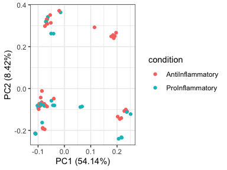

```r
Stim=subset(meta,condition=='AntiInflammatory'|condition=='ProInflammatory')
autoplot(prcomp(t(BDCorrB[,rownames(Stim)])),data=Stim,col='condition')+theme_bw()
```

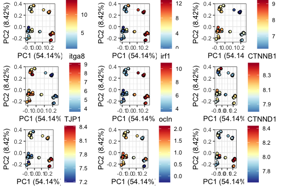

```r
#Stim$cd3e = BDCorrB['ENSG00000198851', rownames(Stim)]
Stim$vcam1 = BDCorrB['ENSG00000162692', rownames(Stim)]
Stim$icam1 = BDCorrB['ENSG00000090339', rownames(Stim)]
Stim$mcam = BDCorrB['ENSG00000076706', rownames(Stim)]
#Stim$ighg2 = BDCorrB['ENSG00000211893', rownames(Stim)]
#Stim$ms4a1 = BDCorrB['ENSG00000156738', rownames(Stim)]
Stim$itga8 = BDCorrB['ENSG00000077943', rownames(Stim)]
Stim$ocln = BDCorrB['ENSG00000197822', rownames(Stim)]
Stim$CTNND1 = BDCorrB['ENSG00000198561', rownames(Stim)]
Stim$TJP1 = BDCorrB['ENSG00000104067', rownames(Stim)]
Stim$CTNNB1 = BDCorrB['ENSG00000168036', rownames(Stim)]
Stim$irf1 = BDCorrB['ENSG00000125347', rownames(Stim)]



a1=autoplot(prcomp(t(BDCorrB[,rownames(Stim)])),data=Stim,fill='vcam1',shape=21)+scale_fill_gradientn(colors=rev(brewer.pal(11,'RdYlBu')))+theme_bw()
a2=autoplot(prcomp(t(BDCorrB[,rownames(Stim)])),data=Stim,fill='icam1',shape=21)+scale_fill_gradientn(colors=rev(brewer.pal(11,'RdYlBu')))+theme_bw()
a3=autoplot(prcomp(t(BDCorrB[,rownames(Stim)])),data=Stim,fill='mcam',shape=21)+scale_fill_gradientn(colors=rev(brewer.pal(11,'RdYlBu')))+theme_bw()
a4=autoplot(prcomp(t(BDCorrB[,rownames(Stim)])),data=Stim,fill='itga8',shape=21)+scale_fill_gradientn(colors=rev(brewer.pal(11,'RdYlBu')))+theme_bw()
a5=autoplot(prcomp(t(BDCorrB[,rownames(Stim)])),data=Stim,fill='irf1',shape=21)+scale_fill_gradientn(colors=rev(brewer.pal(11,'RdYlBu')))+theme_bw()
a6=autoplot(prcomp(t(BDCorrB[,rownames(Stim)])),data=Stim,fill='CTNNB1',shape=21)+scale_fill_gradientn(colors=rev(brewer.pal(11,'RdYlBu')))+theme_bw()
a7=autoplot(prcomp(t(BDCorrB[,rownames(Stim)])),data=Stim,fill='TJP1',shape=21)+scale_fill_gradientn(colors=rev(brewer.pal(11,'RdYlBu')))+theme_bw()
a8=autoplot(prcomp(t(BDCorrB[,rownames(Stim)])),data=Stim,fill='ocln',shape=21)+scale_fill_gradientn(colors=rev(brewer.pal(11,'RdYlBu')))+theme_bw()
#a9=autoplot(prcomp(t(BDCorrB[,rownames(Stim)])),data=Stim,fill='cd24',shape=21)+scale_fill_gradientn(colors=rev(brewer.pal(11,'RdYlBu')))+theme_bw()
a9=autoplot(prcomp(t(BDCorrB[,rownames(Stim)])),data=Stim,fill='CTNND1',shape=21)+scale_fill_gradientn(colors=rev(brewer.pal(11,'RdYlBu')))+theme_bw()

cowplot::plot_grid(a1,a2,a3,a4,a5,a6,a7,a8,a9,ncol=3)
```